# LR vs CF - Predição de Notas

Lívia Cavalcanti

21 de dezembro de 2017

O objetivo do código atual é obter uma predição de notas do quarto período feita a partir de Regressão Linear e compará-la com os resultados obtidos por Filtragem Colaborativa.

# Bibliotecas Utilizadas

```r
library(dplyr)
library(corrplot)
library(GGally)
library(ggplot2)
library(reshape2)
library(caret)
library(mlbench)
library(grid)
```

# Os dados

O tratamento dos dados é o mesmo feito [nesta análise de Collaborative Filtering](http://rpubs.com/liviaCavalcanti/343618), isso porque o objetivo atual é trabalhar com matrizes completas de modo a facilitar a avaliação da predição, por exemplo. Aqui a predição a ser feita é para as notas dos alunos de Ciência da Computação da Universidade Federal de Campina Grande em disciplinas do quarto período.

```r
dados_alunos <- read.csv("../alunosUFCGAnon.csv")
dados_aluno_cc <- dados_alunos %>% filter(Cod_Curso == 14102100 & Cod_Evasao == 0 & Tipo == "Obrigatória")
dados_aluno_cc <- dados_aluno_cc %>% mutate(Matricula = factor(Matricula)) %>% arrange(Matricula) %>%
  select(Matricula, Cod_Disciplina, Nome_Disciplina, Periodo, Creditos, Media_Disciplina, Situacao, Periodo_Ingresso, Periodo_Relativo)
dados_aluno_cc <- dados_aluno_cc %>% group_by(Matricula) %>% mutate(Media = round(mean(Media_Disciplina), digits = 2)) %>% filter(!is.na(Media))
# storing data as factors insures that the modeling functions will treat such data correctly.
# Factors in R are stored as a vector of integer values with a corresponding set of character values to use when the factor is displayed

# Calulo do CRA
alunos_cra <- dados_aluno_cc %>% mutate(Cra.Crontibute = Media*Creditos) %>% summarise(cra = sum(Cra.Crontibute)/sum(Creditos))
alunos_max_media <- dados_aluno_cc %>% group_by(Matricula, Media_Disciplina) %>% filter(Media_Disciplina == max(Media_Disciplina)) %>% ungroup() %>%
  select(Nome_Disciplina, Matricula, Media_Disciplina) %>% mutate(Nome_Disciplina = as.factor(gsub(" ", ".", Nome_Disciplina))) %>%
  dcast(Matricula ~ Nome_Disciplina, mean) %>% merge(alunos_cra)
alunos_max_media <- bind_cols(alunos_max_media,distinct(dados_aluno_cc %>% select(Matricula, Periodo_Ingresso))%>% select(Periodo_Ingresso)) %>% select(-Matricula1)
alunos_graduados <- alunos_max_media[complete.cases(alunos_max_media), ]

##Organizando os data frames principais
# separando alunos por periodo
primeiro_periodo <- alunos_max_media %>% select(Matricula, cra, CALCULO.DIFERENCIAL.E.INTEGRAL.I, ÁLGEBRA.VETORIAL.E.GEOMETRIA.ANALÍTICA, PROGRAMAÇÃO.I,
                                                LABORATÓRIO.DE.PROGRAMAÇÃO.I, INTRODUÇÃO.A.COMPUTAÇÃO, LEITURA.E.PRODUCAO.DE.TEXTOS, Periodo_Ingresso) %>%
  na.omit(primeiro_periodo) %>% arrange(Matricula) %>%
  rename(matricula = Matricula, cra = cra,calculo1 = CALCULO.DIFERENCIAL.E.INTEGRAL.I, vetorial = ÁLGEBRA.VETORIAL.E.GEOMETRIA.ANALÍTICA, p1 = PROGRAMAÇÃO.I,
         lp1 = LABORATÓRIO.DE.PROGRAMAÇÃO.I, ic = INTRODUÇÃO.A.COMPUTAÇÃO, lpt = LEITURA.E.PRODUCAO.DE.TEXTOS)
head(primeiro_periodo)
```

```
##   matricula  cra calculo1 vetorial  p1  lp1   ic lpt Periodo_Ingresso
## 1    B10079 6.37     5.75     5.00 5.0 5.75 7.10 9.5           2007.1
## 2    B10087 1.05     0.00     0.00 0.0 0.00 1.95 7.6           2008.2
## 3    B10088 2.10     0.00     0.15 0.7 0.00 5.20 7.7           2009.2
## 4    B10092 7.10     6.90     4.25 5.0 7.00 7.50 8.5           2009.1
## 5    B10172 4.68     2.70     5.35 6.9 7.10 7.30 8.2           2011.2
## 6    B10192 6.55     5.85     5.00 8.4 8.40 7.80 8.8           2006.1
```

```r
segundo_periodo <- alunos_max_media %>%
  select(Matricula,cra, CALCULO.DIFERENCIAL.E.INTEGRAL.II, FUNDAMENTOS.DE.FÍSICA.CLÁSSICA, TEORIA.DOS.GRAFOS, PROGRAMAÇÃO.II,
         LABORATÓRIO.DE.PROGRAMAÇÃO.II, MATEMÁTICA.DISCRETA) %>% na.omit() %>%
  arrange(Matricula) %>%
  rename(matricula = Matricula, cra = cra,calculo2 = CALCULO.DIFERENCIAL.E.INTEGRAL.II, classica = FUNDAMENTOS.DE.FÍSICA.CLÁSSICA,
         grafos = TEORIA.DOS.GRAFOS, p2 = PROGRAMAÇÃO.II, lp2 = LABORATÓRIO.DE.PROGRAMAÇÃO.II, discreta = MATEMÁTICA.DISCRETA)
head(segundo_periodo)
```

```
##   matricula  cra calculo2 classica grafos   p2 lp2 discreta
## 1    B10079 6.37 4.200000      5.7    7.8 8.90 8.3 4.050000
## 2    B10092 7.10 5.400000      5.0    5.1 6.70 8.2 5.000000
## 3    B10172 4.68 2.033333      5.5    5.5 4.15 3.0 4.666667
## 4    B10192 6.55 5.400000      6.4    5.0 6.00 8.2 5.000000
## 5    B10199 5.86 5.100000      7.8    5.0 6.30 8.7 5.100000
## 6     B1024 5.91 5.000000      5.3    7.6 8.30 8.7 7.000000
```

```r
terceiro_periodo <- alunos_max_media %>%
  select(Matricula,cra, ESTRUTURA.DE.DADOS.E.ALGORITMOS, LAB.DE.ESTRUTURA.DE.DADOS.E.ALGORITMOS, FUNDAMENTOS.DE.FÍSICA.MODERNA,
         ALGEBRA.LINEAR.I,PROBABILIDADE.E.ESTATISTICA, TEORIA.DA.COMPUTAÇÃO, GERÊNCIA.DA.INFORMAÇÃO) %>%
  na.omit() %>%
  arrange(Matricula) %>%
  rename(matricula = Matricula, eda = ESTRUTURA.DE.DADOS.E.ALGORITMOS, leda =  LAB.DE.ESTRUTURA.DE.DADOS.E.ALGORITMOS, moderna =  FUNDAMENTOS.DE.FÍSICA.MODERNA,
         linear = ALGEBRA.LINEAR.I, prob = PROBABILIDADE.E.ESTATISTICA, tc = TEORIA.DA.COMPUTAÇÃO, gi = GERÊNCIA.DA.INFORMAÇÃO)
head(terceiro_periodo)
```

```
##   matricula  cra  eda leda moderna linear prob  tc  gi
## 1    B10092 7.10 6.60  7.9     8.3    6.1  6.0 7.2 7.7
## 2    B10284 7.14 7.00  7.2     8.3    6.1  5.5 6.9 7.0
## 3    B10304 6.17 5.15  7.0     8.5    6.2  1.2 6.9 8.6
## 4    B10443 7.15 7.00  7.7     8.7    7.2  6.8 7.3 7.9
## 5    B10504 7.12 6.70  8.2     8.3    5.0  6.7 7.0 7.1
## 6    B10644 6.07 5.10  5.2     5.0    5.1  5.0 5.3 4.7
```

```r
quarto_periodo <- alunos_max_media %>% select(Matricula, cra, PARADIGMAS.DE.LING..DE.PROGRAMAÇÃO, METODOS.ESTATISTICOS, ORG.E.ARQUITETURA.DE.COMPUTADORES.I,
                                              LAB.DE.ORG.E.ARQUITETURA.DE.COMPUTADORES, LÓGICA.MATEMÁTICA, ENGENHARIA.DE.SOFTWARE.I, SISTEMAS.DE.INFORMAÇÃO.I) %>%
  na.omit() %>%
  arrange(Matricula)%>%
  rename(matricula = Matricula, plp = PARADIGMAS.DE.LING..DE.PROGRAMAÇÃO, metodos = METODOS.ESTATISTICOS, oac = ORG.E.ARQUITETURA.DE.COMPUTADORES.I,
         loac = LAB.DE.ORG.E.ARQUITETURA.DE.COMPUTADORES, logica = LÓGICA.MATEMÁTICA, es = ENGENHARIA.DE.SOFTWARE.I, si1 = SISTEMAS.DE.INFORMAÇÃO.I)
head(quarto_periodo)
```

```
##   matricula  cra plp metodos oac loac logica  es si1
## 1    B10092 7.10 7.0     5.0 7.6  7.1    7.0 6.6 9.3
## 2    B10192 6.55 7.3     5.1 5.8  7.3    6.6 6.3 9.6
## 3    B10199 5.86 5.6     6.5 5.2  8.6    6.2 7.0 5.7
## 4    B10447 8.66 8.1     8.7 8.3  9.2   10.0 9.2 9.6
## 5    B10504 7.12 9.3     6.0 7.2  9.6    8.3 8.1 9.7
## 6    B10644 6.07 5.5     6.4 7.3  8.7    7.0 8.3 8.4
```

```r
# Unindo os periodos
primeiro_segundo_periodos <- merge(primeiro_periodo, segundo_periodo)
head(primeiro_segundo_periodos)
```

```
##   matricula  cra calculo1 vetorial  p1  lp1  ic lpt Periodo_Ingresso
## 1    B10079 6.37 5.750000     5.00 5.0 5.75 7.1 9.5           2007.1
## 2    B10092 7.10 6.900000     4.25 5.0 7.00 7.5 8.5           2009.1
## 3    B10172 4.68 2.700000     5.35 6.9 7.10 7.3 8.2           2011.2
## 4    B10192 6.55 5.850000     5.00 8.4 8.40 7.8 8.8           2006.1
## 5    B10199 5.86 3.666667     6.20 6.1 5.60 7.8 7.0           2005.2
## 6     B1024 5.91 0.000000     5.45 7.5 8.40 7.7 7.0           2010.1
##   calculo2 classica grafos   p2 lp2 discreta
## 1 4.200000      5.7    7.8 8.90 8.3 4.050000
## 2 5.400000      5.0    5.1 6.70 8.2 5.000000
## 3 2.033333      5.5    5.5 4.15 3.0 4.666667
## 4 5.400000      6.4    5.0 6.00 8.2 5.000000
## 5 5.100000      7.8    5.0 6.30 8.7 5.100000
## 6 5.000000      5.3    7.6 8.30 8.7 7.000000
```

```r
# Primeiro, segundo e terceiro periodo
primeiro_a_terceiro_periodo <- merge(primeiro_segundo_periodos, terceiro_periodo)
periodos_dados <- merge(primeiro_a_terceiro_periodo, quarto_periodo) %>% select(matricula, everything())
head(periodos_dados)
```

```
##   matricula  cra calculo1 vetorial  p1 lp1  ic  lpt Periodo_Ingresso
## 1    B10092 7.10     6.90     4.25 5.0 7.0 7.5  8.5           2009.1
## 2    B10504 7.12     4.65     6.30 5.3 7.9 7.6  7.2           2009.1
## 3    B10644 6.07     3.70     5.80 7.0 7.2 8.3  7.2           2010.2
## 4    B10973 6.73     5.60     5.60 7.0 7.7 8.4  6.7           2010.1
## 5    B11044 8.47     8.70     8.60 9.0 8.6 9.1 10.0           2008.1
## 6    B11365 8.35     6.20     8.20 7.9 7.9 9.2  9.3           2010.2
##   calculo2 classica grafos  p2 lp2 discreta eda leda moderna linear prob
## 1 5.400000 5.000000    5.1 6.7 8.2      5.0 6.6  7.9     8.3    6.1  6.0
## 2 5.000000 5.750000    6.3 7.7 5.0      6.3 6.7  8.2     8.3    5.0  6.7
## 3 4.033333 3.266667    7.9 7.6 7.0      6.5 5.1  5.2     5.0    5.1  5.0
## 4 5.900000 7.400000    5.9 7.4 7.0      6.8 7.0  5.0     7.7    6.7  5.2
## 5 8.400000 7.900000    8.2 8.8 9.4      8.3 8.4  9.4     9.4    9.3  7.2
## 6 6.900000 6.900000    9.2 9.1 9.3      7.6 7.1  8.6     8.2    8.3  7.0
##    tc  gi plp metodos oac loac logica   es si1
## 1 7.2 7.7 7.0     5.0 7.6  7.1    7.0 6.60 9.3
## 2 7.0 7.1 9.3     6.0 7.2  9.6    8.3 8.10 9.7
## 3 5.3 4.7 5.5     6.4 7.3  8.7    7.0 8.30 8.4
## 4 7.6 7.7 7.0     8.6 6.6  5.0    5.8 4.75 8.4
## 5 7.8 7.8 6.8     9.0 8.2  8.8   10.0 8.50 8.4
## 6 7.9 7.7 9.4     8.1 8.2 10.0    8.4 9.10 9.4
```

São separados 95% dos dados para treino e guardados seus valores para posterior análise de erro, que devem ser logo em seguidas escondidos no data frame utilizado para predição a fim de que não haja enviesamento da mesma. A matrícula foi transformada em uma sequência numéria mais fácil de ser manipulada.

```r
## Divindo em arquivo de teste e treino
COL_QUARTO_PER <- colnames(quarto_periodo %>% select(-cra, -matricula))
temp <- createDataPartition(periodos_dados$Periodo_Ingresso, p = 0.95, list = F)

# os dados de teste são zerados, copiados para uma nova tabela
# zerando
teste <- periodos_dados

resultados_geral <-teste[-temp,]
resultados <-teste[-temp, COL_QUARTO_PER]
resultados
```

```
##      plp metodos oac loac logica  es si1
## 19  7.20    7.20 7.5  8.3    7.5 8.7 8.3
## 24  5.00    5.40 7.3  7.9    6.8 5.8 8.2
## 27  6.75    4.05 8.3  9.3    7.6 7.0 6.9
## 105 7.00    8.10 7.3  8.3    7.0 8.4 8.0
## 118 8.50    8.10 7.9  8.9    9.2 8.8 9.6
```

```r
for(i in 1:length(COL_QUARTO_PER)) {
  teste[-temp,][COL_QUARTO_PER[i]] <- NA
}

# atribuindo valores numeros as matriculas
teste <- teste %>% bind_cols(matricula_2 = c(1:121)) %>% select(-matricula) %>% select(matricula_2, everything()) %>% rename(matricula = matricula_2)
head(teste)
```

```
##   matricula  cra calculo1 vetorial  p1 lp1  ic  lpt Periodo_Ingresso
## 1         1 7.10     6.90     4.25 5.0 7.0 7.5  8.5           2009.1
## 2         2 7.12     4.65     6.30 5.3 7.9 7.6  7.2           2009.1
## 3         3 6.07     3.70     5.80 7.0 7.2 8.3  7.2           2010.2
## 4         4 6.73     5.60     5.60 7.0 7.7 8.4  6.7           2010.1
## 5         5 8.47     8.70     8.60 9.0 8.6 9.1 10.0           2008.1
## 6         6 8.35     6.20     8.20 7.9 7.9 9.2  9.3           2010.2
##   calculo2 classica grafos  p2 lp2 discreta eda leda moderna linear prob
## 1 5.400000 5.000000    5.1 6.7 8.2      5.0 6.6  7.9     8.3    6.1  6.0
## 2 5.000000 5.750000    6.3 7.7 5.0      6.3 6.7  8.2     8.3    5.0  6.7
## 3 4.033333 3.266667    7.9 7.6 7.0      6.5 5.1  5.2     5.0    5.1  5.0
## 4 5.900000 7.400000    5.9 7.4 7.0      6.8 7.0  5.0     7.7    6.7  5.2
## 5 8.400000 7.900000    8.2 8.8 9.4      8.3 8.4  9.4     9.4    9.3  7.2
## 6 6.900000 6.900000    9.2 9.1 9.3      7.6 7.1  8.6     8.2    8.3  7.0
##    tc  gi plp metodos oac loac logica   es si1
## 1 7.2 7.7 7.0     5.0 7.6  7.1    7.0 6.60 9.3
## 2 7.0 7.1 9.3     6.0 7.2  9.6    8.3 8.10 9.7
## 3 5.3 4.7 5.5     6.4 7.3  8.7    7.0 8.30 8.4
## 4 7.6 7.7 7.0     8.6 6.6  5.0    5.8 4.75 8.4
## 5 7.8 7.8 6.8     9.0 8.2  8.8   10.0 8.50 8.4
## 6 7.9 7.7 9.4     8.1 8.2 10.0    8.4 9.10 9.4
```

```r
# copiando
teste_valores <- teste[-temp, ]
teste_valores
```

```
##     matricula  cra calculo1 vetorial  p1 lp1  ic lpt Periodo_Ingresso
## 19         19 7.55     5.25      7.3 7.9 7.8 7.7 7.6           2009.2
## 24         24 5.67     5.20      5.7 2.7 2.9 7.5 7.7           2006.2
## 27         27 7.68     7.80      9.7 9.1 8.8 9.8 7.3           2008.2
## 105       105 6.53     4.60      5.5 7.0 7.1 8.1 7.5           2011.1
## 118       118 8.04     6.10      7.6 8.0 7.6 8.8 9.8           2008.1
##     calculo2 classica grafos  p2  lp2 discreta eda leda moderna linear
## 19      6.10      7.5    7.6 7.8 9.00     7.00 7.2 8.60     9.7    7.2
## 24      3.75      7.0    5.3 7.0 8.90     3.65 2.5 3.25     7.7    5.7
## 27      8.00      7.5    8.9 9.0 9.10     7.60 7.8 9.30     7.5    7.0
## 105     4.50      4.4    6.2 5.7 5.05     5.90 6.1 6.30     7.3    5.0
## 118     5.00      7.3    7.4 8.8 9.20     7.00 6.0 7.80     8.0    6.8
##     prob   tc  gi plp metodos oac loac logica es si1
## 19  5.10 7.50 7.1  NA      NA  NA   NA     NA NA  NA
## 24  3.95 4.40 7.3  NA      NA  NA   NA     NA NA  NA
## 27  4.05 8.90 8.6  NA      NA  NA   NA     NA NA  NA
## 105 5.00 7.70 5.2  NA      NA  NA   NA     NA NA  NA
## 118 6.10 6.55 8.4  NA      NA  NA   NA     NA NA  NA
```

```r
teste_indices <- rownames(teste_valores)
```

## Predição

A predição é feita com base na correção entre as cadeiras

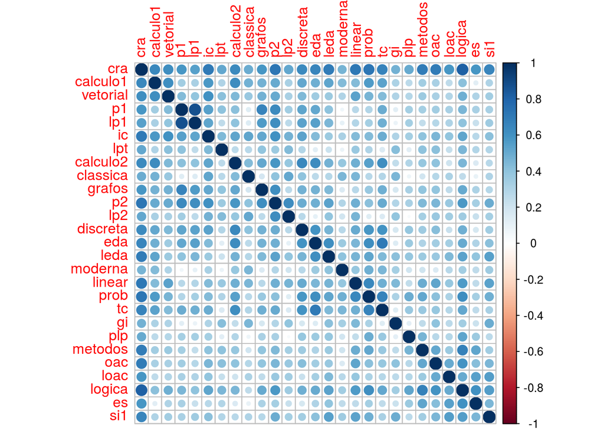

```r
corr_cadeiras <- (periodos_dados %>% select(-matricula, -Periodo_Ingresso) %>% cor())
corrplot(corr_cadeiras)
```

```r
corr_cadeiras <- as.data.frame(corr_cadeiras)
```

Em seguida, considera-se as 10 cadeiras mais semelhantes para cada disciplina do quarto período e controi-se um modelo de Regresão Linear. Que está exemplificado abaixo pela disciplina Organização e Arquitetura de Computadores(OAC). São consideradas doze disciplinas nesse caso, pois a cadeira é semelhante a ela mesma e ao seu respectivo laboratório(Laboratório de Organização e Arquitetura de Computadores - LOAC) que devem ser cursadas simultanemente e devem portanto, serem descartadas para o cálculo do modelo de predição. A mesma lógica segue para as disciplinas do quarto período, a saber: Métodos Estatísticos, Paradigmas de Linguagem de Programação, Lógica Matemática, Engenharia de Software I, Sistemas de Informação I e Laboratório de Organização e Arquitetura de Computadores).

```r
# fazendo predicao para cada cadeira do quarto periodo
# oac
analise_oac <- corr_cadeiras %>% select(oac)
ranking_oac <- cbind(analise_oac, as.data.frame(rownames(analise_oac)))
ranking_oac <- top_n(ranking_oac, 12,oac) %>% rename(cadeiras = "rownames(analise_oac)")
ranking_oac %>% select(cadeiras)
```

```
##    cadeiras
## 1       cra
## 2        ic
## 3        p2
## 4  discreta
## 5    linear
## 6      prob
## 7   metodos
## 8       oac
## 9      loac
## 10   logica
## 11       es
## 12      si1
```

```r
modelo_oac <- lm(oac ~ cra + ic + p2 + discreta + linear + prob + metodos + logica + es + si1, data = teste)
summary(modelo_oac)
```

```
##
## Call:
## lm(formula = oac ~ cra + ic + p2 + discreta + linear + prob +
##     metodos + logica + es + si1, data = teste)
##
## Residuals:
##      Min       1Q   Median       3Q      Max
## -2.96008 -0.49834  0.00693  0.48488  1.92460
##
## Coefficients:
##              Estimate Std. Error t value Pr(>|t|)
## (Intercept)  1.644730   0.796437   2.065 0.041376 *
## cra          1.158142   0.294997   3.926 0.000155 ***
## ic          -0.099129   0.111175  -0.892 0.374619
## p2          -0.168654   0.123735  -1.363 0.175788
## discreta     0.036573   0.078421   0.466 0.641920
## linear       0.067952   0.084502   0.804 0.423128
## prob        -0.226434   0.088398  -2.562 0.011841 *
## metodos      0.008845   0.066050   0.134 0.893726
## logica       0.068728   0.094377   0.728 0.468100
## es          -0.027524   0.077971  -0.353 0.724798
## si1         -0.006861   0.100281  -0.068 0.945581
## ---
## Signif. codes:  0 '***' 0.001 '**' 0.01 '*' 0.05 '.' 0.1 ' ' 1
##
## Residual standard error: 0.8763 on 105 degrees of freedom
##   (5 observations deleted due to missingness)
## Multiple R-squared:  0.5306, Adjusted R-squared:  0.4859
## F-statistic: 11.87 on 10 and 105 DF,  p-value: 1.847e-13
```

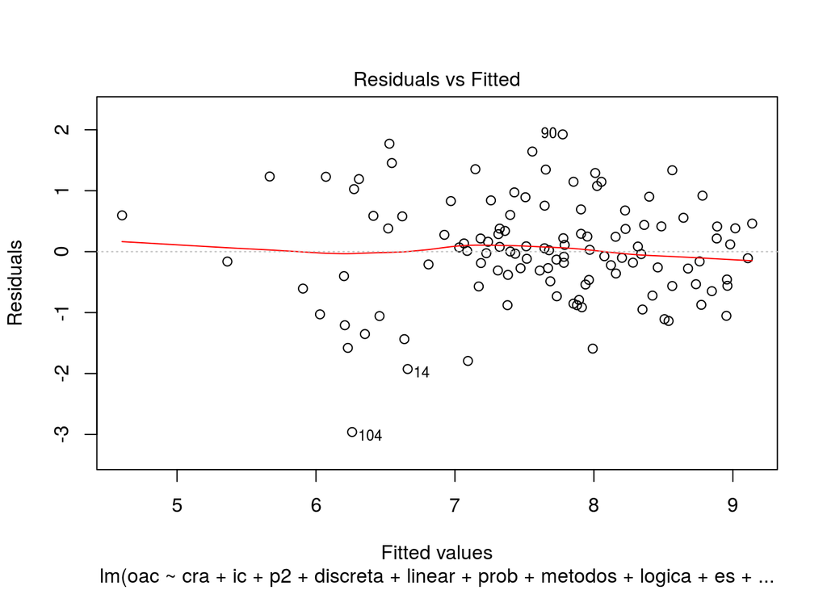

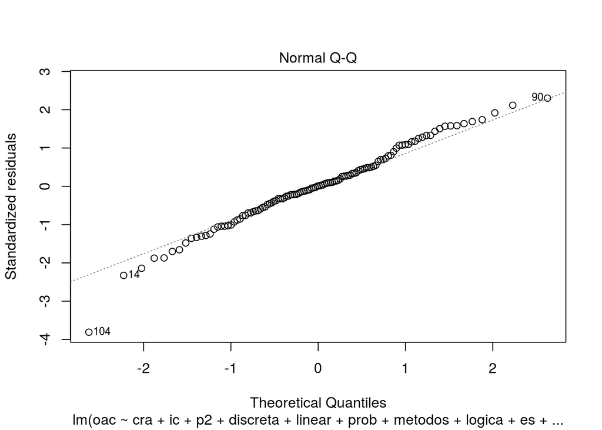

```r
plot(modelo_oac, which = 1:2)
```

A predicação é feita selecionando-se as notas das cadeiras com maior correlação com a disciplina em questão e fazendo a predição com o modelo previamente obtido para os dados de teste. A seguir temos um exemplo do que é feito para as demais disciplinas do período.

```r
# predição
RMSE <- function(predicted, true) mean((predicted-true)^2)^.5

#oac
teste_oac <- resultados_geral %>% select(-matricula, -Periodo_Ingresso, -calculo1, -vetorial, -p1, -lp1, -lpt, -calculo2, -classica, -grafos, -lp2, -eda, -leda, -moderna, -tc, -gi, -plp, -oac)
teste_oac
```

```
##      cra  ic  p2 discreta linear prob metodos loac logica  es si1
## 19  7.55 7.7 7.8     7.00    7.2 5.10    7.20  8.3    7.5 8.7 8.3
## 24  5.67 7.5 7.0     3.65    5.7 3.95    5.40  7.9    6.8 5.8 8.2
## 27  7.68 9.8 9.0     7.60    7.0 4.05    4.05  9.3    7.6 7.0 6.9
## 105 6.53 8.1 5.7     5.90    5.0 5.00    8.10  8.3    7.0 8.4 8.0
## 118 8.04 8.8 8.8     7.00    6.8 6.10    8.10  8.9    9.2 8.8 9.6
```

```r
resultados$oac
```

```
## [1] 7.5 7.3 8.3 7.3 7.9
```

```r
predict(modelo_oac, teste_oac)
```

```
##       19       24       27      105      118
## 8.183094 6.212962 8.204611 7.133142 8.332398
```

```r
RMSE(predict(modelo_oac, teste_oac), resultados$oac)
```

```
## [1] 0.6119116
```

Em seguida, comparou-se os resultados obtidos com as predições através dos métodos de [Filtragem Colaborativa](https://rpubs.com/liviaCavalcanti/337528) e Regressão Linear.

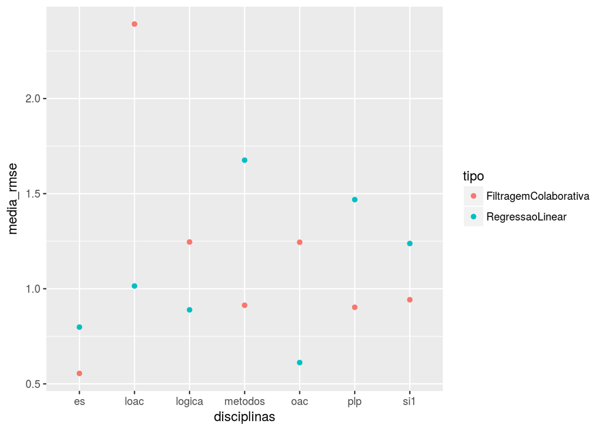

```r
df %>% ggplot(aes(disciplinas, media_rmse,color = tipo)) + geom_point( show.legend = T)
```

Testando-se várias vezes, percebe-se que a análise de melhor método depende da amostra considerada.